# Trabalho Final de Ferramentas Computacionais de Modelagem

# Gráficos

## Histogramas

Histogramas representam a distribuição de frequências de um conjunto de dados. Eles são amplamente utilizados na estatística e na análise de dados para visualizar a forma como os dados estão distribuídos em intervalos ou categorias.

No histograma cada barra representa uma faixa de valores e a altura da barra indica a frequência com que os valores ocorrem nessa faixa. O eixo horizontal do histograma representa as faixas de valores, chamadas de classes, enquanto o eixo vertical representa a contagem ou frequência dos valores em cada classe.

Os histogramas são úteis para identificar padrões, tendências e insights nos dados. Eles permitem visualizar se os dados estão distribuídos de forma simétrica ou assimétrica, se há picos ou outliers, e qual é a concentração dos dados em determinadas faixas.

Neste trabalho, fizemos os histogramas da idade, números de IST (Infecções sexualmente transmissíveis) e uso de anticoncepcional hormonal em anos.

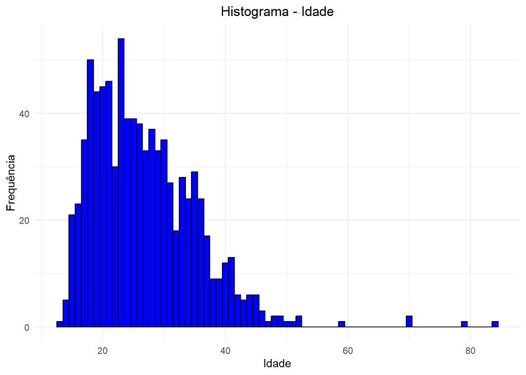

```r
library(ggplot2)

# Carregando o conjunto de dados
dados <- read.csv("dataset.csv")

dados$STDs.number. <- as.numeric(as.character(dados$STDs.number.))
dados$HormonalContraceptivesyears <- as.numeric(as.character(dados$HormonalContraceptivesyears))
theme_set(theme_minimal())

center_title <- theme(plot.title = element_text(hjust = 0.5))

ggplot(dados, aes(x = Age)) +
  geom_histogram(binwidth = 1, fill = "blue", color = "black") +
  labs(x = "Idade", y = "Frequência") +
  scale_fill_brewer(palette = "Blues") +
  center_title +
  labs(title = "Histograma - Idade")
```

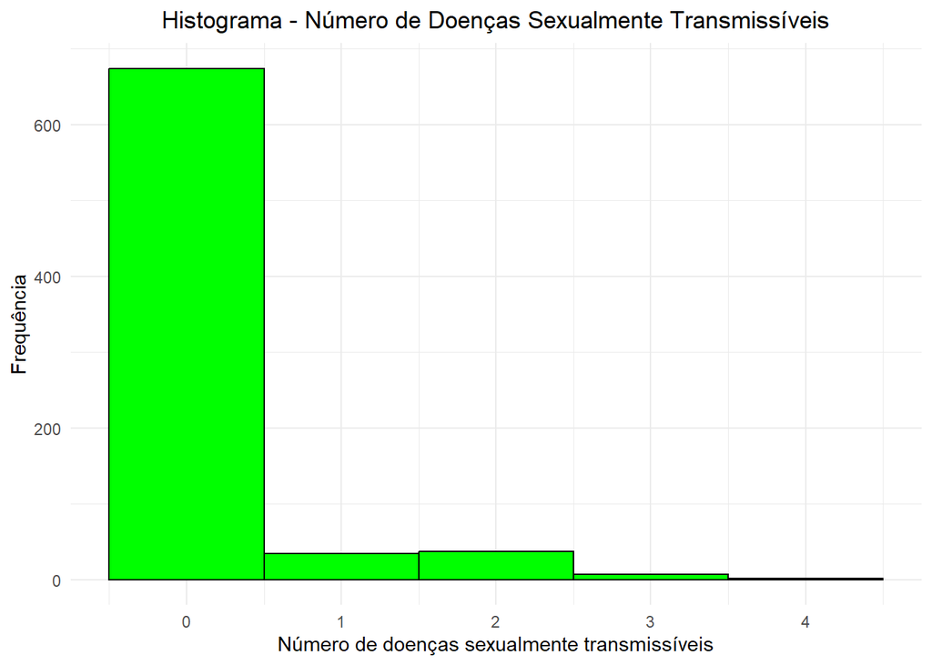

```r
ggplot(dados, aes(x = STDs.number.)) +
  geom_histogram(binwidth = 1, fill = "green", color = "black") +
  labs(x = "Número de doenças sexualmente transmissíveis", y = "Frequência") +
  scale_fill_brewer(palette = "Greens") +
  center_title +
  labs(title = "Histograma - Número de Doenças Sexualmente Transmissíveis")
```

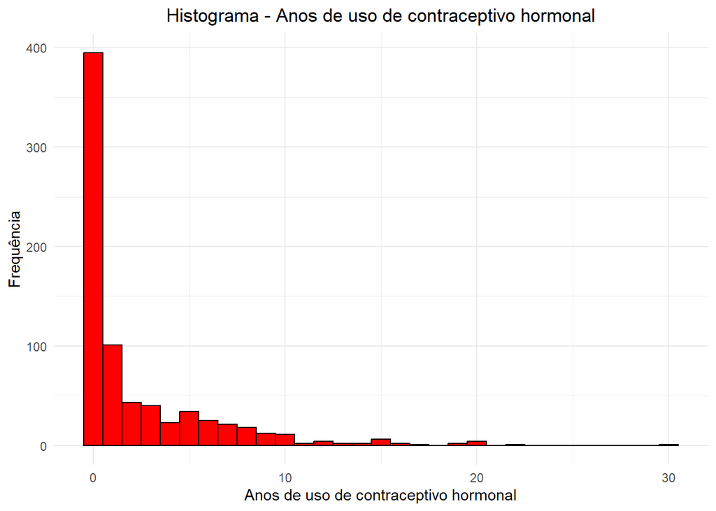

```r
ggplot(dados, aes(x = HormonalContraceptivesyears)) +
  geom_histogram(binwidth = 1, fill = "red", color = "black") +
  labs(x = "Anos de uso de contraceptivo hormonal", y = "Frequência") +
  scale_fill_brewer(palette = "Reds") +
  center_title +
  labs(title = "Histograma - Anos de uso de contraceptivo hormonal")
```

```r
# Salvando em pdf
pdf("histogramas_cervical_cancer.pdf")
dev.off()
```

## Boxplot

O boxplot, também conhecido como diagrama de caixa, é uma representação gráfica que exibe a distribuição estatística de um conjunto de dados. Ele fornece informações sobre a mediana, quartis, valores mínimos e máximos e possíveis valores discrepantes (outliers) presentes nos dados.

O boxplot consiste em um retângulo que é dividido em quartis. A linha central da caixa representa a mediana dos dados, ou seja, o valor que divide o conjunto de dados em duas partes iguais, onde 50% dos dados estão abaixo e 50% estão acima desse valor.

Os quartis são marcados por duas linhas verticais dentro da caixa. O primeiro quartil (Q1) é o valor abaixo do qual 25% dos dados estão localizados, enquanto o terceiro quartil (Q3) é o valor abaixo do qual 75% dos dados estão localizados.

As hastes que se estendem a partir da caixa indicam a variação dos dados. Normalmente, se estendem até o valor mínimo e máximo dos dados que não são considerados outliers.

O boxplot é uma ferramenta visual útil para identificar a dispersão e a presença de valores discrepantes nos dados, permitindo uma compreensão rápida da distribuição estatística de um conjunto de dados.

Para o nosso dataset fizemos os boxplot com a idade, número de parceiros sexuais, primeira relação sexual e o uso de anticoncepcional hormonal em anos.

```r
install.packages("ggplot2")
library(ggplot2)
install.packages("dplyr")
library(dplyr)
Sys.setlocale(category = "LC_ALL", locale = "UTF-8")
```

```
## [1] ""
```

```r
dados <- read.csv("dataset.csv")

#Removendo linhas com valores ausentes
dados <- dados[complete.cases(dados$Numberofsexualpartners), ]

#Convertendo a coluna para numérico
dados$Numberofsexualpartners <- as.numeric(as.character(dados$Numberofsexualpartners))
missing_values <- sum(is.na(dados$Numberofsexualpartners))
print(paste("Valores ausentes na coluna:", missing_values))
```

```
## [1] "Valores ausentes na coluna: 26"
```

```r
#Removendo linhas com valores ausentes
dados <- dados[complete.cases(dados$Numberofsexualpartners), ]

#Convertendo a coluna para numérico
dados$Numberofsexualpartners <- as.numeric(as.character(dados$Numberofsexualpartners))

#Removendo linhas com valores ausentes
dados <- dados[complete.cases(dados$Firstsexualintercourse), ]

#Convertendo a coluna para numérico
dados$Firstsexualintercourse <- as.numeric(as.character(dados$Firstsexualintercourse))
missing_values <- sum(is.na(dados$Firstsexualintercourse))
print(paste("Valores ausentes na coluna:", missing_values))
```

```
## [1] "Valores ausentes na coluna: 5"
```

```r
#Removendo linhas com valores ausentes
dados <- dados[complete.cases(dados$Firstsexualintercourse), ]

#Convertendo a coluna para numérico
dados$Firstsexualintercourse <- as.numeric(as.character(dados$Firstsexualintercourse))

missing_values <- sum(is.na(dados$HormonalContraceptivesyears))
print(paste("Valores ausentes na coluna:", missing_values))
```

```
## [1] "Valores ausentes na coluna: 0"
```

```r
#Removendo linhas com valores ausentes
dados <- dados[complete.cases(dados$HormonalContraceptivesyears), ]

#Convertendo a coluna para numérico
dados$HormonalContraceptivesyears <- as.numeric(as.character(dados$HormonalContraceptivesyears))
```

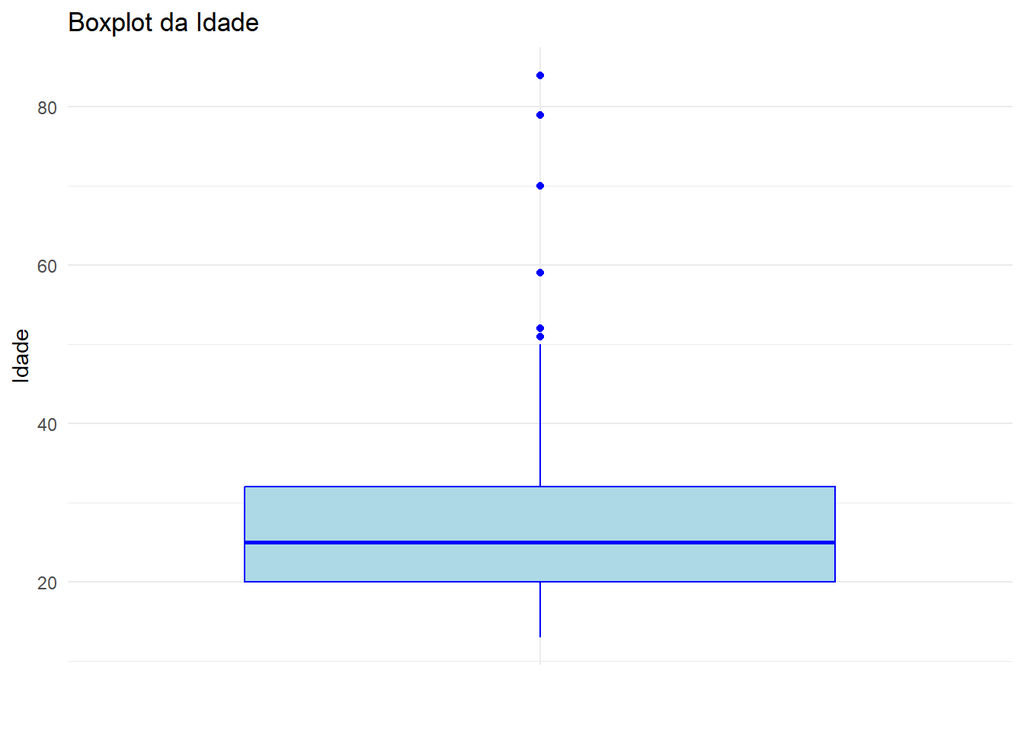

```r
selected_vars <- c("Age", "Numberofsexualpartners", "Firstsexualintercourse", "HormonalContraceptivesyears")
dados_selected <- dados[, selected_vars]

colnames(dados_selected) <- c("Idade", "Número de parceiros sexuais", "Idade da primeira relação sexual", "Uso de anticoncepcional hormonal (anos)")

boxplot_age <- ggplot(dados_selected, aes(x = "", y = Idade)) +
  geom_boxplot(fill = "lightblue", color = "blue") +
  labs(title = "Boxplot da Idade",
       x = "",
       y = "Idade")

boxplot_partners <- ggplot(dados_selected, aes(x = "", y = `Número de parceiros sexuais`)) +
  geom_boxplot(fill = "lightgreen", color = "darkgreen") +
  labs(title = "Boxplot do Número de parceiros sexuais",
       x = "",
       y = "Número de parceiros sexuais")

boxplot_first_sex <- ggplot(dados_selected, aes(x = "", y = `Idade da primeira relação sexual`)) +
  geom_boxplot(fill = "lightpink", color = "red") +
  labs(title = "Boxplot da Idade da primeira relação sexual",
       x = "",
       y = "Idade da primeira relação sexual")

boxplot_hormonal <- ggplot(dados_selected, aes(x = "", y = `Uso de anticoncepcional hormonal (anos)`)) +
  geom_boxplot(fill = "lightyellow", color = "orange") +
  labs(title = "Boxplot do Uso de anticoncepcional hormonal (anos)",
       x = "",
       y = "Uso de anticoncepcional hormonal (anos)")

print(boxplot_age)
```

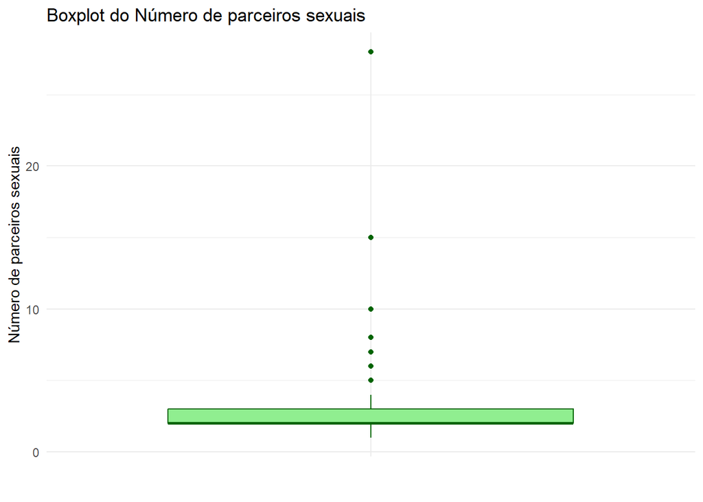

```r
print(boxplot_partners)
```

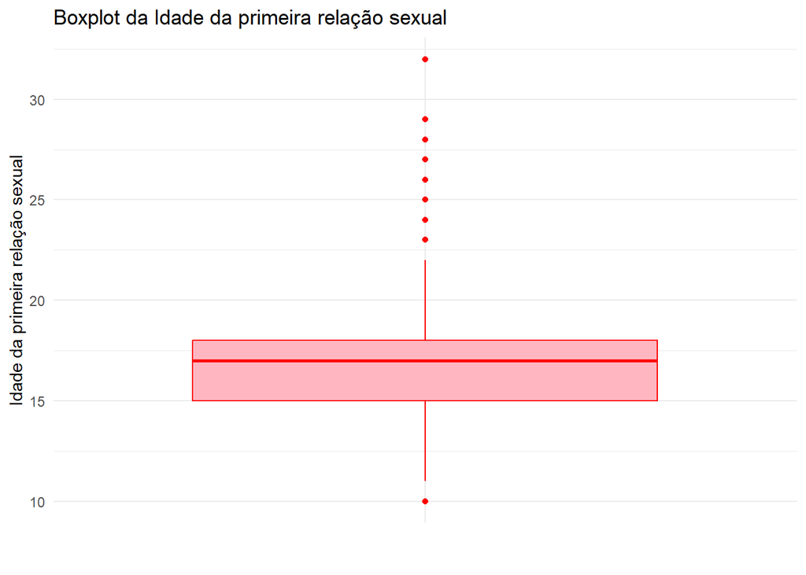

```r
print(boxplot_first_sex)
```

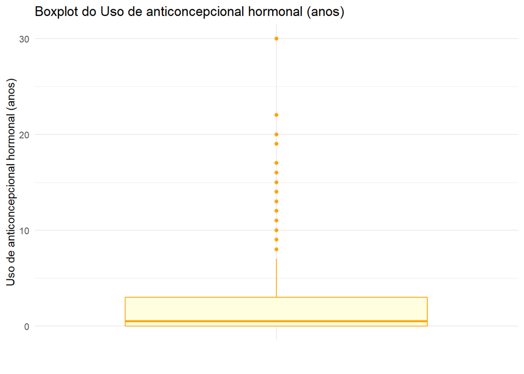

```r
print(boxplot_hormonal)
```

# Testes estatísticos

## Teste t-Student

O teste t de Student é utilizado para comparar as médias de duas amostras independentes. Ele é amplamente utilizado quando queremos avaliar se há diferença significativa entre os grupos.

O teste t de Student é baseado na distribuição t de Student, que é uma distribuição de probabilidade que leva em consideração a variabilidade dos dados amostrais e o tamanho da amostra. Esse teste é apropriado quando as suposições de normalidade e homogeneidade de variâncias são atendidas.

As principais etapas para realizar o teste t de Student são as seguintes:

1. Formulação das hipóteses:
   - Definir a hipótese nula ($H_0$) e a hipótese alternativa ($H_1$). A hipótese nula geralmente afirma que não há diferença entre as médias das duas amostras, enquanto a hipótese alternativa afirma que há diferença.
2. Coleta dos dados:
   - Obter duas amostras independentes, cada uma representando um grupo diferente.
3. Verificação das suposições:
   - Antes de aplicar o teste t de Student, é necessário verificar se as suposições de normalidade e homogeneidade de variâncias são atendidas. Isso pode ser feito por meio de gráficos de normalidade, testes estatísticos ou técnicas de transformação dos dados, se necessário.
4. Cálculo da estatística t:
   - A estatística t é calculada com base nas médias ($\bar{x}_1$, $\bar{x}_2$), desvios padrão ($s_1$, $s_2$) e tamanhos das amostras ($n_1$, $n_2$). A fórmula da estatística t depende do tipo de teste t a ser realizado (teste t de Student para duas amostras independentes, teste t pareado, etc.).
5. Determinação do valor crítico ou p-valor:
   - Com base na estatística t calculada, é possível determinar o valor crítico da distribuição t ou calcular o p-valor, que é a probabilidade de obter uma estatística t igual ou mais extrema do que a observada, sob a hipótese nula.
6. Tomada de decisão:
   - Comparar o valor da estatística t com o valor crítico ou o p-valor com um nível de significância pré-determinado (geralmente 0,05). Se o valor da estatística t estiver além do valor crítico ou o p-valor for menor que o nível de significância, rejeita-se a hipótese nula e conclui-se que há diferença significativa entre as médias das amostras.
7. Relato dos resultados:
   - Com base na decisão tomada, os resultados são relatados juntamente com as conclusões sobre as diferenças (ou não) entre as médias das amostras.

O teste t de Student é amplamente utilizado em várias áreas, incluindo pesquisa médica, ciências sociais, negócios e engenharia, entre outras. É uma ferramenta útil para comparar grupos independentes e determinar se há diferenças estatisticamente significativas entre eles. No entanto, é importante interpretar os resultados com cautela e considerar as suposições e limitações do teste.

**Vamos realizar o mesmo teste t de Student com alguns dados do nosso dataset: Idade, número de parceiros sexuais e uso de contraceptivo hormonal em anos.**

```r
#Importar o dataset
dados <- read.csv("dataset.csv")

#Selecionando as amostras aleatórias de idade, aqui estou utilizando um tamanho de 50 amostras
set.seed(42)
amostra1 <- sample(dados$Age, size = 50)
amostra2 <- sample(dados$Age, size = 50)

#Teste t de Student com as amostras aleatórias do nosso dataset
resultado <- t.test(amostra1, amostra2)
print(resultado)
```

```
##
##  Welch Two Sample t-test
##
## data:  amostra1 and amostra2
## t = -0.79319, df = 84.512, p-value = 0.4299
## alternative hypothesis: true difference in means is not equal to 0
## 95 percent confidence interval:
##  -5.049917  2.169917
## sample estimates:
## mean of x mean of y
##     27.10     28.54
```

```r
# Importando o dataset
dados <- read.csv("dataset.csv")

# Verificando se há valores ausentes na coluna
missing_values <- sum(is.na(dados$Numberofsexualpartners))
print(paste("Valores ausentes na coluna:", missing_values))
```

```
## [1] "Valores ausentes na coluna: 0"
```

```r
#Removendo linhas com valores ausentes
dados <- dados[complete.cases(dados$Numberofsexualpartners), ]

#Convertendo a coluna para numérico
dados$Numberofsexualpartners <- as.numeric(as.character(dados$Numberofsexualpartners))
# Selecionando as amostras aleatórias de número de parceiros sexuais
set.seed(42)
amostra1 <- sample(dados$Numberofsexualpartners, size = 50)
amostra2 <- sample(dados$Numberofsexualpartners, size = 50)

# Teste t de Student com as amostras aleatórias do nosso dataset
resultado <- t.test(amostra1, amostra2)
print(resultado)
```

```
##
##  Welch Two Sample t-test
##
## data:  amostra1 and amostra2
## t = 1.6117, df = 89.599, p-value = 0.1105
## alternative hypothesis: true difference in means is not equal to 0
## 95 percent confidence interval:
##  -0.1012446  0.9714139
## sample estimates:
## mean of x mean of y
##  2.659574  2.224490
```

```r
# Importando o dataset
dados <- read.csv("dataset.csv")

# Verificando se há valores ausentes na coluna
missing_values <- sum(is.na(dados$HormonalContraceptivesyears))
print(paste("Valores ausentes na coluna:", missing_values))
```

```
## [1] "Valores ausentes na coluna: 0"
```

```r
#Removendo linhas com valores ausentes
dados <- dados[complete.cases(dados$HormonalContraceptivesyears), ]

#Convertendo a coluna para numérico
dados$HormonalContraceptivesyears <- as.numeric(as.character(dados$HormonalContraceptivesyears))
# Selecionando as amostras aleatórias de número de parceiros sexuais
set.seed(42)
amostra1 <- sample(dados$HormonalContraceptivesyears, size = 50)
amostra2 <- sample(dados$HormonalContraceptivesyears, size = 50)

# Teste t de Student com as amostras aleatórias do nosso dataset
resultado <- t.test(amostra1, amostra2)
print(resultado)
```

```
##
##  Welch Two Sample t-test
##
## data:  amostra1 and amostra2
## t = -1.069, df = 76.622, p-value = 0.2884
## alternative hypothesis: true difference in means is not equal to 0
## 95 percent confidence interval:
##  -2.5256180  0.7611838
## sample estimates:
## mean of x mean of y
##  2.342667  3.224884
```

## Teste Qui-quadrado

O teste qui-quadrado, também conhecido como teste de independência qui-quadrado, é uma técnica estatística utilizada para avaliar a relação entre duas variáveis categóricas. Ele é aplicado quando queremos verificar se há uma associação significativa entre essas variáveis em uma população.

O teste qui-quadrado é baseado na comparação entre a distribuição observada dos dados e a distribuição esperada caso as variáveis sejam independentes. A hipótese nula assume que as variáveis são independentes, enquanto a hipótese alternativa sugere que existe uma associação entre elas.

O procedimento básico do teste qui-quadrado envolve os seguintes passos:

1. Formular as hipóteses:
   - Hipótese nula ($H_0$): As variáveis são independentes.
   - Hipótese alternativa ($H_1$): As variáveis não são independentes.
2. Coletar os dados e organizar em uma tabela de contingência:
   - A tabela de contingência é uma tabela que mostra a frequência de ocorrência de cada combinação de categorias das duas variáveis. Ela é composta pelas frequências observadas.
3. Calcular as frequências esperadas:
   - Com base nas marginais da tabela de contingência, são calculadas as frequências esperadas para cada combinação de categorias, considerando a hipótese de independência. Essas frequências esperadas representam o que seria esperado se as variáveis fossem independentes.
4. Calcular a estatística qui-quadrado:
   - A estatística qui-quadrado é calculada a partir da comparação entre as frequências observadas e esperadas. Ela mede a discrepância entre essas frequências e indica o grau de associação entre as variáveis.
5. Determinar o valor-p:
   - O valor-p é calculado a partir da estatística qui-quadrado e representa a probabilidade de obter uma estatística tão extrema quanto a observada, considerando a hipótese nula. Um valor-p baixo (geralmente menor que 0,05) sugere que há evidências suficientes para rejeitar a hipótese nula e concluir que as variáveis não são independentes.
6. Interpretar os resultados:
   - Com base no valor-p, podemos tomar uma decisão estatística. Se o valor-p for menor que o nível de significância escolhido (geralmente 0,05), rejeitamos a hipótese nula e concluímos que existe uma associação significativa entre as variáveis. Caso contrário, não temos evidências suficientes para rejeitar a hipótese nula e podemos considerar que as variáveis são independentes.

O teste qui-quadrado é amplamente utilizado em diversas áreas, como ciências sociais, biologia, medicina, marketing, entre outras, para analisar a relação entre variáveis categóricas. Ele fornece uma medida objetiva e estatisticamente fundamentada da associação entre essas variáveis, permitindo a tomada de decisões embasadas em dados.

```r
# Carregar pacote stats
library(stats)

# Lendo o conjunto de dados
dados <- read.csv("dataset.csv")

# Criando tabela de contingência entre duas variáveis categóricas
tabela_contingencia <- table(dados$HormonalContraceptives, dados$Dx.HPV)

# Executando o teste qui-quadrado
resultado_teste <- chisq.test(tabela_contingencia)
# Imprimindo os resultados
print(resultado_teste)
```

```
##
##  Pearson's Chi-squared test
##
## data:  tabela_contingencia
## X-squared = 2.0677, df = 2, p-value = 0.3556
```

```r
# Carregando pacote stats
library(stats)

# Lendo o conjunto de dados
dados <- read.csv("dataset.csv")

# Criando tabela de contingência entre duas variáveis categóricas
tabela_contingencia <- table(dados$HormonalContraceptives, dados$Dx)

# Executando o teste qui-quadrado
resultado_teste <- chisq.test(tabela_contingencia)
# Imprimindo os resultados
print(resultado_teste)
```

```
##
##  Pearson's Chi-squared test
##
## data:  tabela_contingencia
## X-squared = 0.40865, df = 2, p-value = 0.8152
```

```r
# Carregando pacote stats
library(stats)

# Lendo o conjunto de dados
dados <- read.csv("dataset.csv")

# Criando tabela de contingência entre duas variáveis categóricas
tabela_contingencia <- table(dados$Dx, dados$Dx.HPV)

# Executando o teste qui-quadrado
resultado_teste <- chisq.test(tabela_contingencia)
# Imprimindo os resultados
print(resultado_teste)
```

```
##
##  Pearson's Chi-squared test with Yates' continuity correction
##
## data:  tabela_contingencia
## X-squared = 300.36, df = 1, p-value < 2.2e-16
```

*Aqui transformei a coluna de idade de primeira relação sexual em uma coluna de 0 ou 1, aonde 1 significa relações sexuais precoces, antes dos 16 anos e 0 significa após os 16 anos, já que um dos fatores de risco para o câncer de colo de útero é início precoce da vida sexual.*

```r
library(readr)
library(dplyr)

# Lendo o conjunto de dados
dados <- read.csv("dataset.csv") %>%
  mutate(Firstsexualintercourse = ifelse(Firstsexualintercourse < 16, 1, 0))


# Criando tabela de contingência entre duas variáveis categóricas
tabela_contingencia <- table(dados$Dx, dados$Firstsexualintercourse)

# Executando o teste qui-quadrado
resultado_teste <- chisq.test(tabela_contingencia)

# Imprimindo os resultados
print(resultado_teste)
```

```
##
##  Pearson's Chi-squared test with Yates' continuity correction
##
## data:  tabela_contingencia
## X-squared = 1.1563, df = 1, p-value = 0.2822
```

## Teste de correlação de Pearson

O teste de correlação de Pearson é uma técnica estatística utilizada para medir a força e a direção da relação linear entre duas variáveis contínuas. Ele calcula o coeficiente de correlação de Pearson, que varia de -1 a 1, indicando o grau de associação entre as variáveis.

O coeficiente de correlação de Pearson mede a relação linear entre as variáveis, ou seja, se há uma relação linear positiva (quando uma variável aumenta, a outra também aumenta) ou uma relação linear negativa (quando uma variável aumenta, a outra diminui). Um coeficiente de 0 indica que não há correlação linear entre as variáveis.

O teste de correlação de Pearson é amplamente utilizado em análise de dados e pesquisa para explorar e entender as relações entre variáveis. Alguns usos comuns do teste de correlação de Pearson incluem:

Avaliar a relação entre duas variáveis: Ele ajuda a determinar se duas variáveis estão relacionadas de forma linear e a quantificar a força dessa relação.

Identificar padrões nos dados: O coeficiente de correlação de Pearson permite identificar se existe uma relação linear forte ou fraca entre as variáveis. Isso pode ser útil para detectar padrões nos dados e compreender as relações entre diferentes fenômenos.

Selecionar variáveis em análises multivariadas: Ao realizar análises multivariadas, como regressão linear, o teste de correlação de Pearson pode ser usado para identificar quais variáveis têm uma relação significativa com a variável dependente. Isso auxilia na seleção das variáveis mais relevantes para o modelo.

*Aqui vamos analisar a correlação entre o número de parceiros sexuais e a presença de infecções sexualmente transmissíveis; a correlação entre o hábito de fumar e o diagnóstico de câncer; e também a correlação entre a idade e o número de gestações.*

```r
library(readr)
library(dplyr)

# Lendo o conjunto de dados
dados <- read.csv("dataset.csv")

# Verificando se há valores ausentes na coluna
missing_values <- sum(is.na(dados$Numberofsexualpartners))
print(paste("Valores ausentes na coluna:", missing_values))
```

```
## [1] "Valores ausentes na coluna: 0"
```

```r
#Removendo linhas com valores ausentes
dados <- dados[complete.cases(dados$Numberofsexualpartners), ]

#Convertendo a coluna para numérico
dados$Numberofsexualpartners <- as.numeric(as.character(dados$Numberofsexualpartners))
# Verificando se há valores ausentes na coluna
missing_values <- sum(is.na(dados$STDs.number.))
print(paste("Valores ausentes na coluna:", missing_values))
```

```
## [1] "Valores ausentes na coluna: 0"
```

```r
#Removendo linhas com valores ausentes
dados <- dados[complete.cases(dados$STDs.number.), ]

#Convertendo a coluna para numérico
dados$STDs.number. <- as.numeric(as.character(dados$STDs.number.))
#Teste de correlação de Pearson
cor.test(dados$Numberofsexualpartners,dados$STDs.number.)
```

```
##
##  Pearson's product-moment correlation
##
## data:  dados$Numberofsexualpartners and dados$STDs.number.
## t = 1.126, df = 737, p-value = 0.2605
## alternative hypothesis: true correlation is not equal to 0
## 95 percent confidence interval:
##  -0.03077009  0.11322308
## sample estimates:
##        cor
## 0.04144168
```

```r
library(readr)
library(dplyr)

# Lendo o conjunto de dados
dados <- read.csv("dataset.csv")

# Verificando se há valores ausentes na coluna
missing_values <- sum(is.na(dados$Smokes.years.))
print(paste("Valores ausentes na coluna:", missing_values))
```

```
## [1] "Valores ausentes na coluna: 0"
```

```r
#Removendo linhas com valores ausentes
dados <- dados[complete.cases(dados$Smokes.years.), ]

#Convertendo a coluna para numérico
dados$Smokes.years. <- as.numeric(as.character(dados$Smokes.years.))
# Verificando se há valores ausentes na coluna
missing_values <- sum(is.na(dados$Dx.Cancer))
print(paste("Valores ausentes na coluna:", missing_values))
```

```
## [1] "Valores ausentes na coluna: 0"
```

```r
#Removendo linhas com valores ausentes
dados <- dados[complete.cases(dados$Dx.Cancer), ]

#Convertendo a coluna para numérico
dados$Dx.Cancer <- as.numeric(as.character(dados$Dx.Cancer))

cor.test(dados$Smokes.years.,dados$Dx.Cancer)
```

```
##
##  Pearson's product-moment correlation
##
## data:  dados$Smokes.years. and dados$Dx.Cancer
## t = 1.6353, df = 843, p-value = 0.1024
## alternative hypothesis: true correlation is not equal to 0
## 95 percent confidence interval:
##  -0.01125084  0.12320913
## sample estimates:
##        cor
## 0.05623412
```

```r
library(readr)
library(dplyr)

# Lendo o conjunto de dados
dados <- read.csv("dataset.csv")

# Verificando se há valores ausentes na coluna
missing_values <- sum(is.na(dados$Age))
print(paste("Valores ausentes na coluna:", missing_values))
```

```
## [1] "Valores ausentes na coluna: 0"
```

```r
#Removendo linhas com valores ausentes
dados <- dados[complete.cases(dados$Age), ]

#Convertendo a coluna para numérico
dados$Age <- as.numeric(as.character(dados$Age))

# Verificando se há valores ausentes na coluna
missing_values <- sum(is.na(dados$Numofpregnancies))
print(paste("Valores ausentes na coluna:", missing_values))
```

```
## [1] "Valores ausentes na coluna: 0"
```

```r
#Removendo linhas com valores ausentes
dados <- dados[complete.cases(dados$Numofpregnancies), ]

#Convertendo a coluna para numérico
dados$Numofpregnancies <- as.numeric(as.character(dados$Numofpregnancies))
#Teste de correlação de Pearson
cor.test(dados$Age,dados$Numofpregnancies)
```

```
##
##  Pearson's product-moment correlation
##
## data:  dados$Age and dados$Numofpregnancies
## t = 18.571, df = 800, p-value < 2.2e-16
## alternative hypothesis: true correlation is not equal to 0
## 95 percent confidence interval:
##  0.4985719 0.5954584
## sample estimates:
##       cor
## 0.5488558
```

### Tabela de Classificação do Coeficiente de Correlação de Pearson

Categorização para os valores do coeficiente de correlação de Pearson

| Coeficiente de Correlação | Classificação |
| --- | --- |
| 0 < r ≤ \|0,1\| | Nula |
| \|0,1\| < r ≤ \|0,3\| | Fraca |
| \|0,3\| < r ≤ \|0,6\| | Moderada |
| \|0,6\| < r ≤ \|0,9\| | Forte |
| \|0,9\| < r < \|1\| | Muito Forte |
| r = 1 | Perfeita |